# General Social Survey

Jose Guzman

October 7 2019

# 1 Introduction Question 1

This data is from the 2018 General Social Survey. The first blocks of R-code has selected down a subset of the data to just 15 variables. It has further removed unwanted factor levels in much of the data. Examine that code to see what it is doing. Finally address this question. Is opinion on the death penalty (CAPPUN) independent of gun ownership (OWNGUN)?

## 1.1 Methods

both variables in this analysis are catergorical; hence we use bar graphs and tables to summarize the date, and a chi-squared test for inference.

$H_0$ : There is no relationship between gun ownership and whether once is in favor of capital punishment.

$H_A$ : There is a relationship between gun ownership and whether once is in favor of capital punishment.

## 1.2 Results

### 1.2.1 Descriptive Results

#### 1.2.1.1 Graphical Descriptive Results

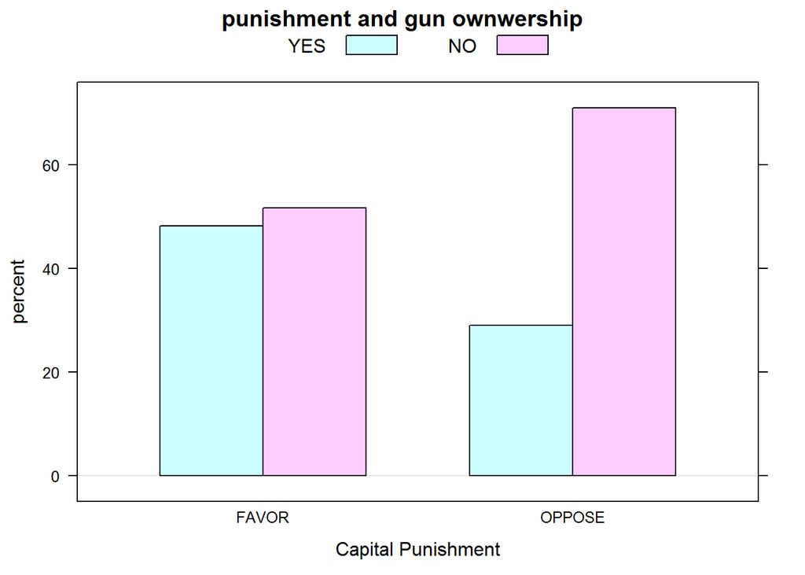

```r
barchartGC(~CAPPUN+OWNGUN, data=mydata4, main='punishment and gun ownwership', type='percent', xlab='Capital Punishment')
```

This barchart shows that there is a higher percentage of people who oppose capital punishment and do not own a gun than those who are in favor.

#### 1.2.1.2 Numerical Descriptive Results

```r
tab1= xtabs(~CAPPUN+OWNGUN, data=mydata4)
rowPerc(tab1)
```

```
##         OWNGUN
## CAPPUN      YES     NO  Total
##   FAVOR   48.28  51.72 100.00
##   OPPOSE  29.03  70.97 100.00
```

This table shows that more people do not own a gun whether or not they are in favor of capital punishment.

### 1.2.2 Inferential Results

```r
chisqtestGC(tab1)
```

```
## Pearson's Chi-squared test with Yates' continuity correction
##
## Observed Counts:
##         OWNGUN
## CAPPUN   YES NO
##   FAVOR   56 60
##   OPPOSE  18 44
##
## Counts Expected by Null:
##         OWNGUN
## CAPPUN     YES    NO
##   FAVOR  48.22 67.78
##   OPPOSE 25.78 36.22
##
## Contributions to the chi-square statistic:
##         OWNGUN
## CAPPUN    YES   NO
##   FAVOR  1.25 0.89
##   OPPOSE 2.35 1.67
##
##
## Chi-Square Statistic = 5.3932
## Degrees of Freedom of the table = 1
## P-Value = 0.0202
```

Now answer Is belief in the bigbang theory (BIGBANG) independent of belief in the afterlife (POSTLIFE)

## 1.3 Methods

For this analysis we use bar graphs and tables to summarize the date, and a chi-squared test for inference.

$H_0$ : There is no relationship between belief in the big bang theory and belief in post life

$H_A$ : There is a relationship between belief in the big bang theory and belief in post life

## 1.4 Results

### 1.4.1 Descriptive Results

#### 1.4.1.1 Graphical Descriptive Results

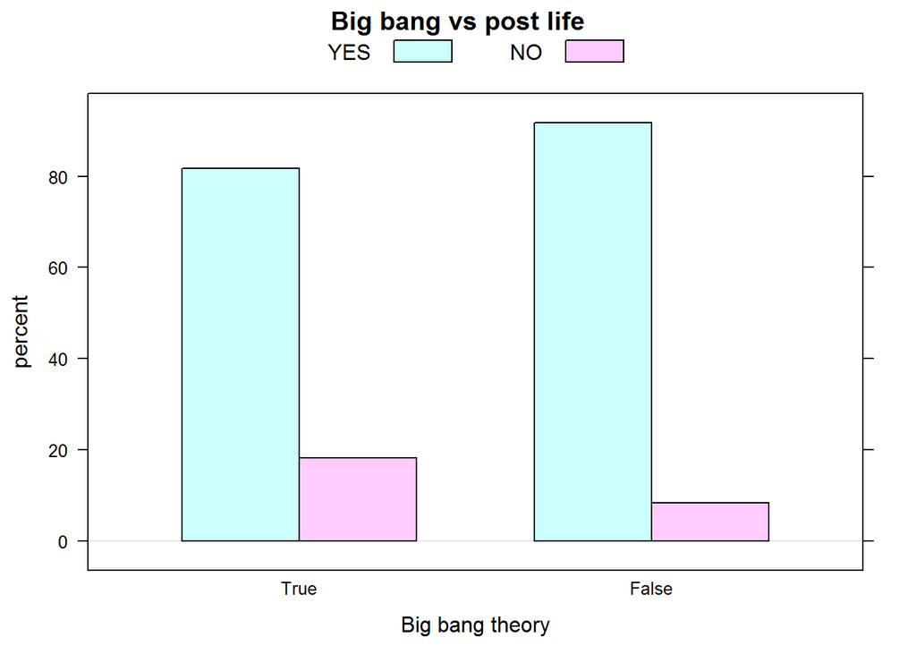

```r
barchartGC(~BIGBANG+POSTLIFE, data=mydata4, main='Big bang vs post life', type='percent', xlab='Big bang theory')
```

This barchart shows that the percentage of those who believe in postlife as well as the big bang theory is about the same.

#### 1.4.1.2 Numerical Descriptive Results

```r
tab1= xtabs(~BIGBANG+POSTLIFE, data=mydata4)
rowPerc(tab1)
```

```
##        POSTLIFE
## BIGBANG    YES     NO  Total
##   True   81.71  18.29 100.00
##   False  91.67   8.33 100.00
```

This numerical table shows that there is a higher number of those who believe in post life with roughly 82 also believing in the bigbang and about 92 who do not believe in the big bang.

### 1.4.2 Inferential Results

```r
chisqtestGC(tab1)
```

```
## Pearson's Chi-squared test with Yates' continuity correction
##
## Observed Counts:
##        POSTLIFE
## BIGBANG YES NO
##   True   67 15
##   False  88  8
##
## Counts Expected by Null:
##        POSTLIFE
## BIGBANG  YES   NO
##   True  71.4 10.6
##   False 83.6 12.4
##
## Contributions to the chi-square statistic:
##        POSTLIFE
## BIGBANG  YES   NO
##   True  0.27 1.83
##   False 0.23 1.56
##
##
## Chi-Square Statistic = 3.0637
## Degrees of Freedom of the table = 1
## P-Value = 0.0801
```

The -p value for the chisq test is 0.0801 > ..05 so we fail to reject the null hypotheis and conclude we do not have evidence to support the contention that the belief in the bigbang theory and afterlife are related.

# 2 Introduction Question 3

Finally determine if a persons opinion on death penalty (CAPPUN) is independent of their race (RACE).

## 2.1 Methods

For this analysis we use bar graphs and tables to summarize the date, and a chi-squared test for inference.

$H_0$ : There is no relationship between one’s opinion on the death penalty and their race.

$H_A$ : There is a relationship between one’s opinion on the death penalty and their race.

## 2.2 Results

### 2.2.1 Descriptive Results

#### 2.2.1.1 Graphical Descriptive Results

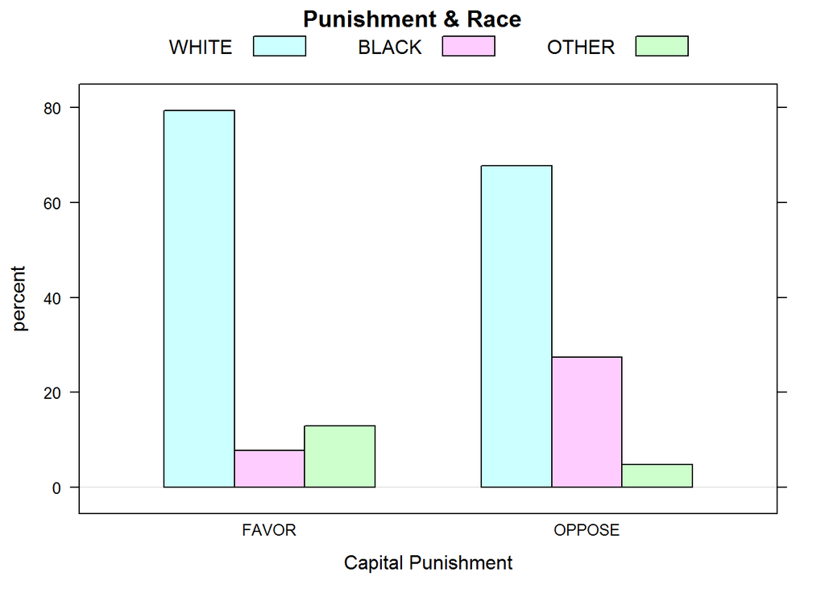

```r
barchartGC(~CAPPUN+RACE, data=mydata4, main='Punishment & Race', type='percent', xlab='Capital Punishment')
```

#### 2.2.1.2 Numerical Descriptive Results

```r
tab1= xtabs(~CAPPUN+RACE, data=mydata4)
rowPerc(tab1)
```

```
##         RACE
## CAPPUN    WHITE  BLACK  OTHER  Total
##   FAVOR   79.31   7.76  12.93 100.00
##   OPPOSE  67.74  27.42   4.84 100.00
```

This numerical table shows that therer are more white in favor with 79 than in opposition with about 68. There is also a higher number of those in opposition for blacks, with 27 than those in favor, with 8.

### 2.2.2 Inferential Results

```r
chisqtestGC(tab1)
```

```
## Pearson's Chi-squared test
##
## Observed Counts:
##         RACE
## CAPPUN   WHITE BLACK OTHER
##   FAVOR     92     9    15
##   OPPOSE    42    17     3
##
## Counts Expected by Null:
##         RACE
## CAPPUN   WHITE BLACK OTHER
##   FAVOR  87.33 16.94 11.73
##   OPPOSE 46.67  9.06  6.27
##
## Contributions to the chi-square statistic:
##         RACE
## CAPPUN   WHITE BLACK OTHER
##   FAVOR   0.25  3.72  0.91
##   OPPOSE  0.47  6.97  1.71
##
##
## Chi-Square Statistic = 14.0272
## Degrees of Freedom of the table = 2
## P-Value = 9e-04
```

# 3 Discussion and Conclusion

IS there a relationship between gun ownership and whether once is in favor of capital punishment? The p-value for the Chisq test is 0.02 < ..05 so we reject the null hypothesis and conclude we have evidence to support the contention that gun owner ship and whether on favors capital punishment are related.

IS there a relationship between belief in the big bang theory and belief in post life? The -p value for the chisq test is 0.0801 > ..05 so we fail to reject the null hypotheis and conclude we do not have evidence to support the contention that the belief in the bigbang theory and afterlife are related.